# STAT 650 - Final - Regression Analysis on World Happiness Report

## 1. Tanishq Dayma - 332009488

## 2. Introduction

### Research Interest:

The research interest aims in predicting happiness scores for a new country in 2023 and, more importantly, in understanding why happiness matters globally and the factors that contribute to happiness.

### Significance

Predicting happiness scores for a new country in 2023 is not just about numbers; it's about understanding a fundamental aspect of well-being that holds global significance. The importance of happiness as a factor goes beyond statistical predictions for several reasons like quality of life, societal well-being, economic factors, and health.

### Goal:

The primary goal is to create predictive models for forecasting happiness scores in 2023. It will include achieving below two main goals:

1. The research aims to pinpoint the specific economic, social, and psychological factors that is responsible for the 2023 World Happiness Scores for various countries.
2. To assess the precision and reliability of the predictive models employed for predicting happiness scores in the year 2023.

### Objectives:

To achieve above two goals below objectives have to be taken into consideration:

**Goal 1:** The research aims to pinpoint the specific economic, social, and psychological factors that is responsible for the 2023 World Happiness Scores for various countries.

1. Analysis on the importance of each variable for 2023 World Happiness Report. A thorough analysis to identify how the social indicator like 'Generosity' contribute to predicting happiness scores in 2023.

   **Hypotheses:**
   - *Null Hypothesis (H0):* The variable 'Generosity' has no significant impact on happiness scores.
   - *Alternative Hypothesis (H1):* The variable 'Generosity' has a significant impact on happiness scores.
2. Utilize feature selection EDA techniques like corelation analysis and scatter plots to precisely identify and enhance the efficiency of predictors within our model.

**Goal 2:** Model Implementation and Evaluation

1. Assess the accuracy and reliability of the predictive model for happiness scores in 2023 using appropriate validation techniques such as comparison of Mean Squared Error (MSE), Root Mean Squared Error (RMSE), and R-squared.
2. Predict the Happiness Score of a New Country with the Best Model  
   Utilize the best-performing predictive model identified through model evaluation and analysis and predict the happiness score of a new country based on the model's learned patterns and insights.

### Theoretical Background of the Project - World Happiness Report

The theoretical foundation for predicting happiness scores is based on an in-depth understanding of psychology, society, and economics. Psychological theories, such as subjective well-being, place emphasis on cognitive assessments and emotional experiences. Sociological viewpoints investigate the impact of social support and perceptions of corruption or in other words trust in government, whereas economic indicators like GDP per capita represent affluence and quality of life. Theoretical concerns also include aspects like liberty, independence, and the changing character of happiness throughout time.

In predictive modeling, this comprehensive approach includes subjective and objective factors. Regression analysis is used to determine the importance of various factors. Theoretical insights influence the selection of variables, providing valuable input for policy recommendations. Interpreting model results within a larger context aims at advancing social well-being and happiness on a societal level.

## 3. Data Description

### Source of the data

The dataset being used for this analysis can be found at the below link: https://worldhappiness.report/data/

**Citation**  
Helliwell, J. F., Layard, R., Sachs, J. D., Aknin, L. B., De Neve, J.-E., & Wang, S. (Eds.). (2023). World Happiness Report 2023 (11th ed.). Sustainable Development Solutions Network.

### Characteristics of this data:

1. The Happiness Score can be influenced by multiple dimensions, hence the data is multidimensional in nature.
2. The target variable has dependence on economic, social, health, and freedom related factors.

### Definition of variables:

**Primary columns:**  
**1. Country name:** The name of the country under consideration. Each data row represents a different country.

**2. Ladder score:** It measures a country's level of happiness or quality of life. A higher value suggests a higher level of fulfillment.

**3. Standard error of ladder score:** This is a measurement of the standard error for the "Ladder score." It contributes to the accuracy of the outcomes.

**4. upperwhisker:** This is the upper bound of the confidence interval for the "Ladder score."

**5. lowerwhisker:** This is the lower bound of the confidence interval for the "Ladder score."

**6. Logged GDP per capita:** It reflects the logged Gross Domestic Product (GDP) per capita, a measure of the country's economic well-being.

**7. Social support:** It denotes the degree of social support or social aid available to people of the country.

**8. Healthy life expectancy:** It indicates the predicted length of a healthy life, showing how many years people in that nation may expect to live in good health.

**9. Freedom to make life choices:** It assesses the degree of freedom people have in making life decisions in their respective countries.

**10. Generosity:** It is a measure of generosity or people's eagerness to help others.

**11. Perceptions of corruption:** It examines people's perceptions of the country's level of corruption. A higher rating might suggest a stronger impression of corruption.

**Additional Columns** **12. Ladder score in Dystopia:** This is a hypothetical degree of happiness or quality of life in severely adverse conditions known as "Dystopia."

**13. Explained by: Log GDP per capita:** The portion of the "Ladder score" that is explained by the logarithm of GDP per capita.

**14. Explained by: Social support:** It determines how much of the "Ladder score" is explained by social support.

**15. Explained by: Healthy life expectancy:** Describes how the projected healthy life expectancy impacts the "Ladder score."

**16. Explained by: Freedom to make life choices:** Explains the importance of freedom in decision-making in connection to the "Ladder score."

**17. Explained by: Generosity:** It determines how much of the "Ladder score" is explained by generosity.

**18. Explained by: Perceptions of corruption:** This explains how perceptions of corruption influence the "Ladder score."

**19. Dystopia + residual:** This is the total of the values from the "Ladder score in Dystopia" column and the remaining residual impacts that have not been accounted for in other explanations (such as climate, culture, history, and many other personal factors for the country).

### Type of Variables:

To understand the data, I have used dtypes method of pandas and below is the output. All the variables other than the 'Country Name' are continuous quantitative variables represented as float64 below.

| Column | Data Type | Variable Type |
| --- | --- | --- |
| Country name | object | Nominal Qualitative Variable |
| Ladder score | float64 | Continuous Quantitative Variable |
| Standard error of ladder score | float64 | Continuous Quantitative Variable |
| upperwhisker | float64 | Continuous Quantitative Variable |
| lowerwhisker | float64 | Continuous Quantitative Variable |
| Logged GDP per capita | float64 | Continuous Quantitative Variable |
| Social support | float64 | Continuous Quantitative Variable |
| Healthy life expectancy | float64 | Continuous Quantitative Variable |
| Freedom to make life choices | float64 | Continuous Quantitative Variable |
| Generosity | float64 | Continuous Quantitative Variable |
| Perceptions of corruption | float64 | Continuous Quantitative Variable |
| Ladder score in Dystopia | float64 | Continuous Quantitative Variable |
| Explained by: Log GDP per capita | float64 | Continuous Quantitative Variable |
| Explained by: Social support | float64 | Continuous Quantitative Variable |
| Explained by: Healthy life expectancy | float64 | Continuous Quantitative Variable |
| Explained by: Freedom to make life choices | float64 | Continuous Quantitative Variable |
| Explained by: Generosity | float64 | Continuous Quantitative Variable |
| Explained by: Perceptions of corruption | float64 | Continuous Quantitative Variable |
| Dystopia + residual | float64 | Continuous Quantitative Variable |

### Data Preprocessing:

**DataFrame In Use:**

First let's check out how the dataframe and first five rows of the table looks like:

| Country name | Ladder score | Standard error of ladder score | upperwhisker | lowerwhisker | Logged GDP per capita | Social support | Healthy life expectancy | Freedom to make life choices | Generosity | Perceptions of corruption | Ladder score in Dystopia | Explained by: Log GDP per capita | Explained by: Social support | Explained by: Healthy life expectancy | Explained by: Freedom to make life choices | Explained by: Generosity | Explained by: Perceptions of corruption | Dystopia + residual |
| --- | --- | --- | --- | --- | --- | --- | --- | --- | --- | --- | --- | --- | --- | --- | --- | --- | --- | --- |
| Finland | 7.8042 | 0.036162 | 7.875078 | 7.733322 | 10.792010 | 0.968770 | 71.149994 | 0.961408 | -0.018824 | 0.181745 | 1.777825 | 1.888380 | 1.584900 | 0.534574 | 0.771510 | 0.126331 | 0.535299 | 2.363241 |
| Denmark | 7.5864 | 0.041028 | 7.666815 | 7.505985 | 10.962164 | 0.954112 | 71.250145 | 0.933533 | 0.134242 | 0.195814 | 1.777825 | 1.949406 | 1.547875 | 0.537302 | 0.734416 | 0.208459 | 0.525221 | 2.083766 |
| Iceland | 7.5296 | 0.048612 | 7.624879 | 7.434321 | 10.895531 | 0.982533 | 72.050018 | 0.936349 | 0.210987 | 0.667848 | 1.777825 | 1.925508 | 1.619666 | 0.559096 | 0.738164 | 0.249635 | 0.187119 | 2.250382 |
| Israel | 7.4729 | 0.031609 | 7.534853 | 7.410946 | 10.638705 | 0.943344 | 72.697205 | 0.808866 | -0.023080 | 0.708094 | 1.777825 | 1.833398 | 1.520674 | 0.576730 | 0.568518 | 0.124048 | 0.158292 | 2.691290 |
| Netherlands | 7.4030 | 0.029294 | 7.460416 | 7.345583 | 10.942279 | 0.930499 | 71.550018 | 0.886875 | 0.212686 | 0.378929 | 1.777825 | 1.942274 | 1.488228 | 0.545473 | 0.672327 | 0.250547 | 0.394062 | 2.110044 |

The shape of the table contains 137 rows and 19 columns. For quantitative variables, generate a table for the count, mean, standard deviation, minimum and maximum values and the quantities of the data.

|  | Ladder score | Standard error of ladder score | upperwhisker | lowerwhisker | Logged GDP per capita | Social support | Healthy life expectancy | Freedom to make life choices | Generosity | Perceptions of corruption | Ladder score in Dystopia | Explained by: Log GDP per capita | Explained by: Social support | Explained by: Healthy life expectancy | Explained by: Freedom to make life choices | Explained by: Generosity | Explained by: Perceptions of corruption | Dystopia + residual |
| --- | --- | --- | --- | --- | --- | --- | --- | --- | --- | --- | --- | --- | --- | --- | --- | --- | --- | --- |
| **count** | 137.000000 | 137.000000 | 137.000000 | 137.000000 | 137.000000 | 137.000000 | 136.000000 | 137.000000 | 137.000000 | 137.000000 | 137.000000 | 137.000000 | 136.000000 | 137.000000 | 137.000000 | 137.000000 | 137.000000 | 136.000000 |
| **mean** | 5.539755 | 0.064672 | 5.666513 | 5.412998 | 9.449785 | 0.799045 | 64.967627 | 0.787427 | 0.022444 | 0.725375 | 1.777825 | 1.406995 | 1.156171 | 0.366125 | 0.539989 | 0.148474 | 0.145914 | 1.777825 |
| **std** | 1.139908 | 0.023005 | 1.117421 | 1.163709 | 1.207315 | 0.129188 | 5.750394 | 0.112350 | 0.141711 | 0.176960 | 0.000000 | 0.433000 | 0.326333 | 0.156679 | 0.149506 | 0.076035 | 0.126750 | 0.504389 |
| **min** | 1.859000 | 0.028552 | 1.922712 | 1.795288 | 5.526723 | 0.341341 | 51.530212 | 0.381642 | -0.254276 | 0.146112 | 1.777825 | 0.000000 | 0.000000 | 0.000000 | 0.000000 | 0.000000 | 0.000000 | -0.109798 |
| **25%** | 4.723900 | 0.046871 | 4.980320 | 4.495800 | 8.590914 | 0.722042 | 60.648690 | 0.723874 | -0.073543 | 0.667848 | 1.777825 | 1.098963 | 0.961660 | 0.248448 | 0.455417 | 0.096972 | 0.059591 | 1.555550 |
| **50%** | 5.684300 | 0.060127 | 5.796732 | 5.529228 | 9.567472 | 0.827064 | 65.837624 | 0.800536 | 0.001419 | 0.773583 | 1.777825 | 1.449203 | 1.226947 | 0.389829 | 0.557434 | 0.137193 | 0.111384 | 1.848350 |
| **75%** | 6.333800 | 0.077148 | 6.441343 | 6.243341 | 10.540300 | 0.895955 | 69.412264 | 0.874468 | 0.117025 | 0.845892 | 1.777825 | 1.798105 | 1.400968 | 0.487226 | 0.655817 | 0.199221 | 0.187119 | 2.078302 |
| **max** | 7.804200 | 0.146538 | 7.875078 | 7.733322 | 11.659949 | 0.982533 | 77.279778 | 0.961408 | 0.531386 | 0.929089 | 1.777825 | 2.199664 | 1.619666 | 0.701590 | 0.771510 | 0.421545 | 0.560821 | 2.954561 |

### Data Quality Check and Preprocessing

After understanding the basic details about the data, following preprocessing tasks need be performed:

#### Dropping Unwanted Variables:

Making sub-dataset from the original dataset for our research interest and goals by dropping unnecessary variables. Below columns were dropped because they are not serving any purpose to our research.

Exclusion of Columns: Ladder score in Dystopia and Explanatory Variables

The column **"Ladder score in Dystopia"** is excluded from the analysis due to its zero variance, representing a hypothetical condition. Since this variable does not contribute to the variation in the data, it is not considered informative for predictive modeling.

Additionally, the following columns, namely **"Standard error of ladder score", "upperwhisker", "lowerwhisler, "Explained by: Log GDP per capita," "Explained by: Social support," "Explained by: Healthy life expectancy," "Explained by: Freedom to make life choices," "Explained by: Generosity," "Explained by: Perceptions of corruption,"** and **"Dystopia + residual,"** are omitted from the predictive analysis.

These columns serve as explanatory variables, providing insights into the calculation of the target variable rather than directly influencing it. Therefore, excluding them will streamline the analysis by focusing on the core predictors directly affecting the target variables.

#### Renaming columns:

To enhance the clarity of the dataset, certain columns have been renamed to provide more intuitive and meaningful names.

| Original Column Name | Renamed Column Name |
| --- | --- |
| Country name | Country |
| Ladder score | HappinessScore |
| Logged GDP per capita | GDPperCapita |
| Social support | SocialSupport |
| Healthy life expectancy | LifeExpectancy |
| Freedom to make life choices | FreedomToMakeLifeChoices |
| Perceptions of corruption | Corruption |

#### Checking for Duplicates and Null Values

- No duplicated values were found in the dataset.
- Null values were identified in the 'LifeExpectancy' column. The dataset summary for null values is as follows:

| Country | Number of null values |
| --- | --- |
| HappinessScore | 0 |
| GDPperCapita | 0 |
| SocialSupport | 0 |
| LifeExpectancy | 1 |
| FreedomToMakeLifeChoices | 0 |
| Generosity | 0 |
| Corruption | 0 |

*After handling null values - Output becomes*

| Country | Number of null values |
| --- | --- |
| HappinessScore | 0 |
| GDPperCapita | 0 |
| SocialSupport | 0 |
| LifeExpectancy | 0 |
| FreedomToMakeLifeChoices | 0 |
| Generosity | 0 |
| Corruption | 0 |

##### Preprocessed Dataset

The first few rows of the preprocessed dataset are as follows:

| Country | HappinessScore | GDPperCapita | SocialSupport | LifeExpectancy | FreedomToMakeLifeChoices | Generosity | Corruption |
| --- | --- | --- | --- | --- | --- | --- | --- |
| Finland | 7.8042 | 10.792010 | 0.968770 | 71.149994 | 0.961408 | -0.018824 | 0.181745 |
| Denmark | 7.5864 | 10.962164 | 0.954112 | 71.250145 | 0.933533 | 0.134242 | 0.195814 |
| Iceland | 7.5296 | 10.895531 | 0.982533 | 72.050018 | 0.936349 | 0.210987 | 0.667848 |
| Israel | 7.4729 | 10.638705 | 0.943344 | 72.697205 | 0.808866 | -0.023080 | 0.708094 |
| Netherlands | 7.4030 | 10.942279 | 0.930499 | 71.550018 | 0.886875 | 0.212686 | 0.378929 |

These steps ensure the dataset is free from duplicates and missing values, providing a foundation for further analysis.

#### Checking Outliers and Generate Box Plots

After Checking the Outliers for each of the quantitative variables, below results were obtained.

- Country is a qualitative variable
- HappinessScore has 0 outliers
- GDPperCapita has 0 outliers
- SocialSupport has 1 outliers
- LifeExpectancy has 0 outliers
- FreedomToMakeLifeChoices has 1 outliers
- Generosity has 1 outliers
- Corruption has 0 outliers

The presence of outliers can be visualized more intuitively through the Box Plots for each variable:

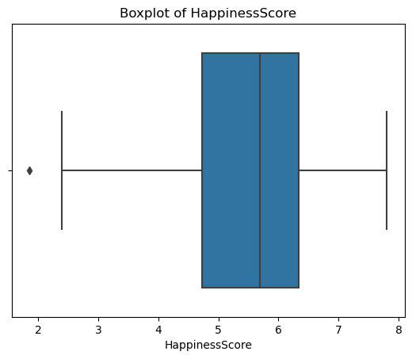

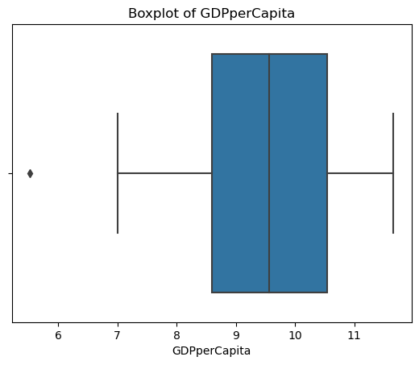

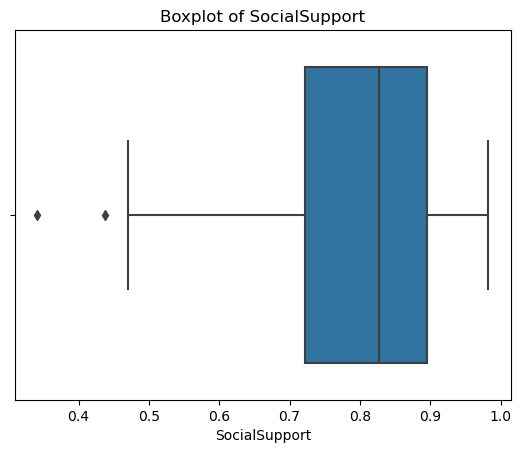

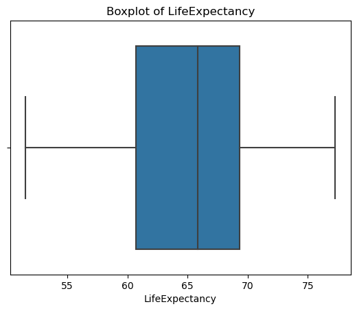

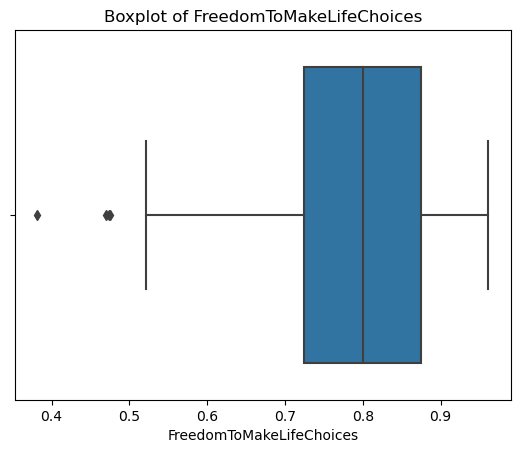

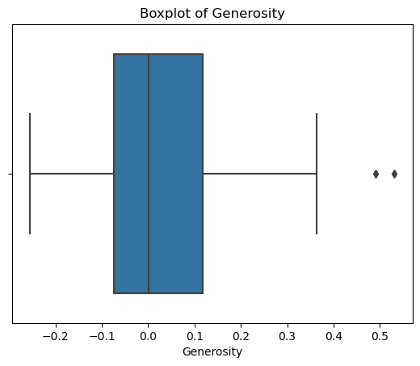

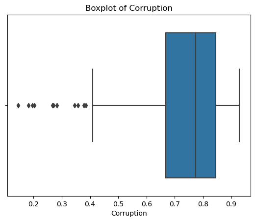

As observed that the dataset exhibits minimal outliers. Given this, no further action is deemed necessary as these outliers are not expected to significantly impact the results of our predictive modeling.

### Exploratory Data Analysis (EDA) Results

- This also serves as the Objective 2 of our Goal 1, 'Feature Selection Utilize feature selection EDA techniques like corelation analysis and scatter plots to precisely identify and enhance the efficiency of predictors within our model.'

During the Exploratory Data Analysis (EDA) phase, various analyses were performed to gain insights into the characteristics of the dataset. Here are the key observations:

**1. Histogram of Variabes:**

Utilizing histograms for each variable, the distribution and frequency of values were examined. The dataset showcases a general overview of the distribution of happiness scores and other quantitative factors. The histograms provided initial insights into the shape and spread of the data.

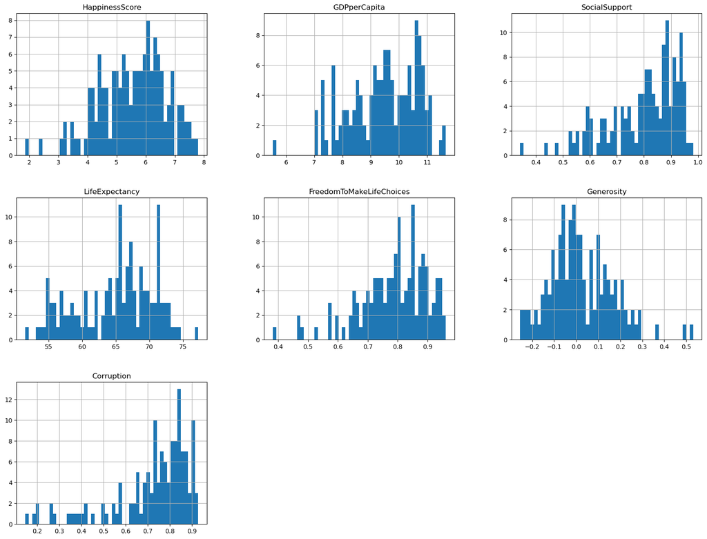

**2. Corelation Matrix:**

A correlation matrix was generated to explore the relationships between variables. The heatmap visualization allowed us to identify significant correlations, providing a foundation for understanding interdependencies.

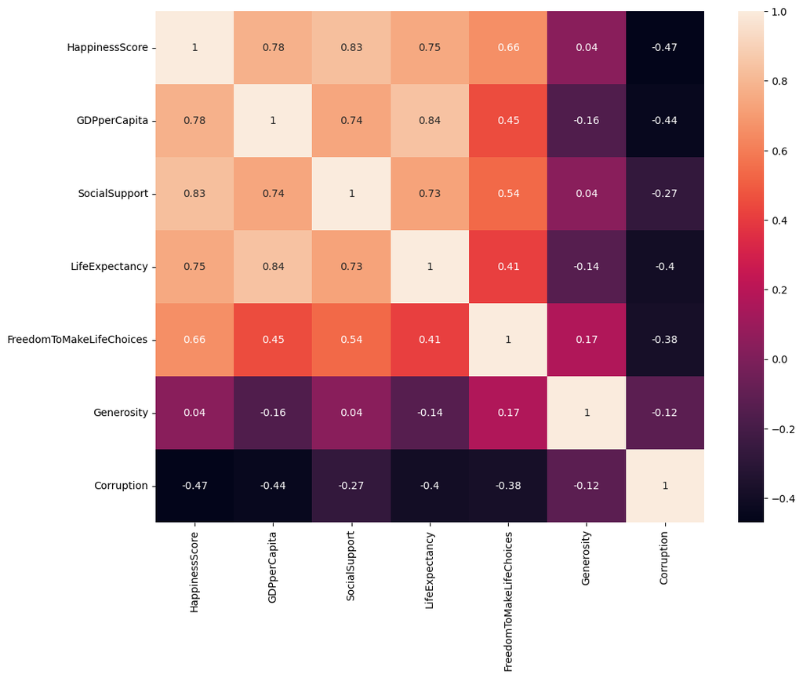

|  | Happiness Score |
| --- | --- |
| **Happiness Score** | 1.000000 |
| **Social Support** | 0.834623 |
| **GDP per Capita** | 0.784368 |
| **Life Expectancy** | 0.745412 |
| **Freedom to Make Life Choices** | 0.662922 |
| **Generosity** | 0.043687 |
| **Corruption** | -0.471976 |

**Insights:**

1. **Strong Positive Correlations:**
   - *Happiness Score & Social Support (0.83):* Countries with higher social support tend to have higher happiness scores, indicating the importance of social connections in overall well-being.
   - *Happiness Score & GDP per Capita (0.78):* Economic prosperity, as measured by GDP per capita, correlates positively with happiness scores, suggesting financial well-being contributes significantly.
2. **Moderate Positive Correlations:**
   - *Happiness Score & Life Expectancy (0.75):* A positive correlation signifies that nations with better life expectancy tend to have higher happiness scores, indicating a link between health and happiness.
   - *Happiness Score & Freedom to Make Life Choices (0.66):* Countries where individuals have more freedom to make life choices demonstrate a positive association with happiness.
3. **Weak Correlation:**
   - *Happiness Score & Generosity (0.04):* The correlation is weak, suggesting that generosity has a limited impact on overall happiness scores.
4. **Negative Correlation:**
   - *Happiness Score & Corruption (-0.47):* A notable negative correlation indicates that higher levels of corruption are associated with lower happiness scores, emphasizing the detrimental impact of corruption on societal well-being.

This correlation matrix provides valuable insights into the relationships between key factors and the overall happiness scores, guiding further analysis and interpretation in the context of our research goals.

**3. Scatter Plots with Regression Lines:**

Scatter plots with regression lines were used to visualize the relationship between Happiness Score and key factors, namely GDP per Capita, Social Support, Life Expectancy, Freedom to Make Life Choices, Generosity, and Corruption. These plots offer a graphical representation of the potential impact of these factors on happiness.

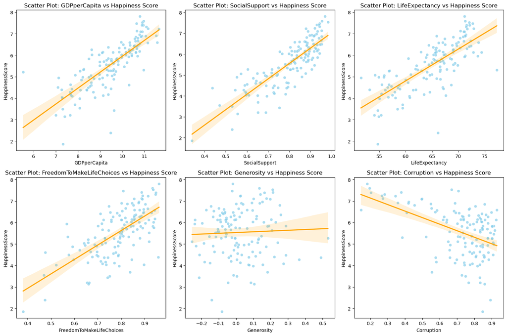

**Observation:**

### Scatterplot Analysis:

Observing the scatterplot relationships between Happiness Score and various factors:

1. **Positive Slope:**
   - Positive slopes in the scatterplots for GDP per Capita, Social Support, Life Expectancy, and Freedom to Make Life Choices signify a direct and positive correlation, indicating that as the variable increases, the Happiness Score also tends to increase.
2. **Relatively Flat Line:**
   - *Generosity:* The scatterplot shows a relatively flat line, suggesting that the level of generosity has a limited impact on overall happiness scores.
3. **Negative Slope:**
   - *Corruption:* The scatterplot reveals a negative slope, indicating that higher levels of corruption are associated with lower happiness scores.

These observations align with the correlation matrix findings, providing a visual representation of the relationships between each variable and happiness scores.

## 3. Methodology

### Analytical Methods

In this project, various statistical and modeling techniques were used to understand and predict the World Happiness Scores for different countries in 2023.

1. **Data Preprocessing:**
   - Standard Scaling: Applied Standard Scaler to normalize selected columns, such as GDPperCapita, SocialSupport, LifeExpectancy, FreedomToMakeLifeChoices, Generosity, and Corruption. It transforms the data to have a mean of 0 and a standard deviation of 1, ensuring that all features contribute equally to the analysis.

     Why - By dividing our World Happiness Report data into two sets—one for training the model and the other for testing—we can assess how effectively the model predicts happiness scores for countries it hasn't seen before. This ensures that our model generalizes well to new data, enhancing its reliability.
2. **Regression Models:**
   - Linear Regression: Utilized linear regression as a baseline model to establish a simple relationship between the target variable - Happiness Score and all the other variables.

     Why - It helps in the interpretation of the relationship between the features and the target variable which can act as a benchmark for all the other models.
   - Lasso Regression: Applied Lasso regression for feature selection and regularization by adding a penalty term to the coefficients based on their impact on the target variable.

     Why - Lasso helps in selecting the most relevant features by setting the coefficients of less important features to zero. This aids in simplifying the model and reducing the risk of overfitting.
   - Ridge Regression: Ridge regression is used when we want to mitigate issues like mu multicollinearity when independent variables are highly correlated.

     Why - This is important for our analysis to ensure that the relationships between various factors influencing happiness scores are accurately captured without being overly influenced by correlations among those factors.
   - Elastic Net Regression: Used Elastic Net regression as it combines the strengths of both Lasso and Ridge regression techniques.

     Why - In our analysis, it allows us to simultaneously address multicollinearity concerns and identify the most influential factors contributing to happiness scores, offering a comprehensive approach to model regularization.
   - Polynomial Regression: It is used as it helps capture non-linear relationships between independent and dependent variables.

     Why - In instances where the association between features (such as GDP per capita, social support, life expectancy, etc.) and the happiness score is not strictly linear, polynomial regression enables the model to account for more intricate patterns.

### Model Evaluation and Selection

#### Choice of Features or Feature Selection Strategy

In crafting our feature set (X variable), we've omitted 'Country' and 'HappinessScore.' The rationale behind excluding 'Country' is rooted in its categorical nature, unique to each row, making it unsuitable for direct quantitative analysis. As for 'HappinessScore,' it is our target variable.

In contrast, the 'y' variable, representing our target variable, exclusively centers around the 'HappinessScore' which is the key metric of interest.

#### Evaluation Metrics

- **Mean Squared Error (MSE):** Calculated the MSE for each model to measure the average squared difference between predicted and actual values. Lower MSE values indicate better model performance. However, since MSE is not in the same scale as the original data, it might be less interpretable compared to RMSE.
- **Root Mean Squared Error (RMSE):** Computed the RMSE as the square root of the average of the squared differences between predicted and actual values. It provides a single, easy-to-interpret measure of how well the model is performing, with lower RMSE values indicating better accuracy.
- **R-squared (R2):** Evaluated the R2 score to assess the proportion of variance explained by the models. In general, a higher R2 is desirable, as it suggests that the model is better at explaining and predicting the observed outcomes.

#### Model Comparison

- ## Model Performance Comparison

In assessing the performance of different regression models, various metrics were considered for evaluating their predictive capabilities. The following table summarizes the mean squared error (MSE), root mean squared error (RMSE), and ( R2) values for linear, LASSO, ridge, elastic net, and polynomial regression models:

##### Mean Squared Error (MSE):

| Model | MSE |
| --- | --- |
| Linear | 0.3017 |
| LASSO | 1.1405 |
| Ridge | 0.3017 |
| Elastic Net | 0.6395 |
| Polynomial | 0.3870 |

##### Root Mean Squared Error (RMSE):

| Model | RMSE |
| --- | --- |
| Linear | 0.5493 |
| LASSO | 1.0679 |
| Ridge | 0.5492 |
| Elastic Net | 0.7997 |
| Polynomial | 0.6221 |

##### ( R2 ) Values:

| Model | ( R2) |
| --- | --- |
| Linear | 0.7383 |
| LASSO | 0.0107 |
| Ridge | 0.7383 |
| Elastic Net | 0.4453 |
| Polynomial | 0.6643 |

### Interpretation:

- The Linear model shows good predictive performance with an (R2) value of 0.7383, indicating that 73.83% of the variability in the World Happiness Scores is explained by the model.
- LASSO regression and Elastic Net, on the other hand, performs poorly with a very low (R2) values, suggesting that they are not effective in capturing the underlying patterns in the data.
- Ridge regression exhibit similar performance to the Linear model, providing effective predictions with (R2) values close to that of the Linear model.
- Polynomial regression also performs well, with an (R2) value of 0.6643, indicating its ability to capture non-linear relationships in the data.

In summary, the Linear, Ridge, and Polynomial regression models demonstrate promising results, while LASSO and Elastic Net regression seems less suitable for this particular dataset.

After observing the initial results, areas for improvement are identified for LASSO and Elastic Net. It is discussed in the next section.

### Model Improvement

In an effort to enhance the predictive performance of the regression models, regularization techniques were applied along with hyperparameter tuning.

#### Regularization:

- Lasso Regression:
  - Applied L1 regularization (Lasso) and optimized hyperparameters using cross-validation.
  - Best Alpha after Cross Validation: 0.0001.
  - Mean Squared Error after Cross Validation: 0.3017
- Elastic Net Regression:
  - Utilized Elastic Net regression with grid search to fine-tune hyperparameters.
  - Best Alpha: 0.21000000000000002.
  - Mean Squared Error after Hyper parameter Tuning: 0.2918

### Performance Metrics After Model Improvement

Below table displays the performance metrics of the LASSO and Elastic Net regression models after the model improvement:

##### Mean Squared Error (MSE):

| Model | MSE |
| --- | --- |
| LASSO (Hyperparameter Tuning) | 0.3017 |
| Elastic Net (Hyperparameter Tuning) | 0.2918 |

##### Root Mean Squared Error (RMSE):

| Model | RMSE |
| --- | --- |
| LASSO (Hyperparameter Tuning) | 0.5492 |
| Elastic Net (Hyperparameter Tuning) | 0.5402 |

##### ( R2 ) Values:

| Model | (R2) |
| --- | --- |
| LASSO (Hyperparameter Tuning) | 0.7383 |
| Elastic Net (Hyperparameter Tuning) | 0.7469 |

### Best Model Selection

After thorough evaluation and model improvement, the Elastic Net regression model with hyperparameter tuning stands out as the best-performing model for predicting World Happiness Scores in 2023. Below are the reasons supporting this choice:

###### Reasons:

- The Elastic Net model with hyperparameter tuning achieved the lowest MSE among all models, indicating superior accuracy in predicting happiness scores.
- The Elastic Net model also demonstrated the lowest RMSE, which reflects the closeness of predicted values to the observed values.
- The (R2) value for the Elastic Net model after hyperparameter tuning is the highest among all the models.

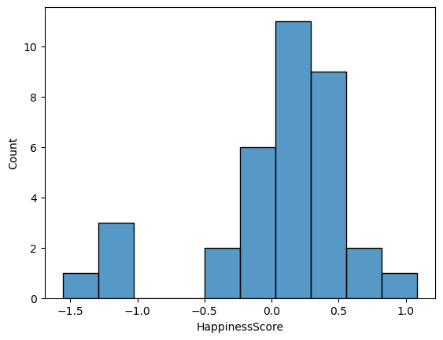

###### Coefficients Analysis:

**Coefficients Table for the Elastic Net Model:**

| Feature | Coefficient |
| --- | --- |
| GDPperCapita | 0.264489 |
| SocialSupport | 0.388657 |
| LifeExpectancy | 0.140318 |
| FreedomToMakeLifeChoices | 0.192782 |
| Generosity | -0.000000 |
| Corruption | -0.096863 |

### Goal 1, Objective 1: Hypothesis Testing:

The null hypothesis (H0) states that the variable 'Generosity' has no significant impact on happiness scores. The alternative hypothesis (H1) suggests that 'Generosity' has a significant impact on happiness scores.

The coefficient for 'Generosity' is close to zero (-0.000000), supporting the null hypothesis. This implies that 'Generosity' does not significantly contribute to the prediction of happiness scores.

### Model Prediction for a Hypothetical Country

- Next, generating the happiness score for a hypothetical country using the trained Elastic Net model.
- These are the values being used to generate a prediction for a hypothetical country for each variable, the new data is scaled accordingly:
- GDPperCapita: 10.228
- SocialSupport: 0.842
- LifeExpectancy: 65.700
- FreedomToMakeLifeChoices: 0.916
- Generosity: 0.121
- Corruption: 0.782

**The predicted Happiness Score through the Elastic Net Model is approximately 6.04.**

These steps helped understand the data, improve model performance, and optimize predictive models through an iterative process.

## 5. Results and Interpretation

### Model Performance

The analysis involved training and evaluating various regression models to predict happiness scores for countries in 2023. The models considered include linear regression, LASSO regression, ridge regression, elastic net regression, and polynomial regression. The performance metrics, such as Mean Squared Error (MSE), Root Mean Squared Error (RMSE), and R-squared, were utilized for model evaluation.

### Model Comparison

| Model | MSE | RMSE | (R2) |
| --- | --- | --- | --- |
| Linear | 0.3017 | 0.5493 | 0.7383 |
| LASSO (Hyperparameter Tuning) | 0.3017 | 0.5492 | 0.7383 |
| Ridge | 0.3017 | 0.5492 | 0.7383 |
| Elastic Net (Hyperparameter Tuning) | 0.2918 | 0.5402 | 0.7469 |
| Polynomial | 0.3870 | 0.6221 | 0.6643 |

### Statistical Significance

- The Elastic Net model, with hyperparameter tuning, stands out as the best-performing model in terms of lower MSE, RMSE, and higher R2.
- The similarity in performance among Linear, LASSO, and Ridge models suggests robustness in capturing the relationships in the data.
- The Polynomial model, with its comparatively higher errors, may not be the optimal choice for this specific dataset.

In conclusion, the statistical significance is evident in the model comparison, highlighting the superiority of the Elastic Net model in predicting happiness scores for countries in 2023.

### Interpretation of Coefficients

#### Coefficients for Best Model (Elastic Net)

The coefficients for the best predictive model (Elastic Net) showcase the impact of each feature on predicting happiness scores in 2023.

| Feature | Coefficient |
| --- | --- |
| GDPperCapita | 0.2645 |
| SocialSupport | 0.3887 |
| LifeExpectancy | 0.1403 |
| FreedomToMakeLifeChoices | 0.1928 |
| Generosity | -0.0000 |
| Corruption | -0.0969 |

### Interpretation and Implications

The interpretation of coefficients aligns with the exploratory data analysis (EDA) and our logical thought process during the analysis.

The positive coefficients for GDP per Capita, Social Support, Life Expectancy, and Freedom to Make Life Choices confirm the patterns observed in the EDA phase. These variables were identified as influential factors in predicting happiness scores. The positive impact suggests that higher values of these features contribute to higher happiness scores, reinforcing the understanding gained through visualizations and correlation analyses.

The negligible impact of Generosity, indicated by its coefficient close to zero, corresponds with our EDA findings. Despite being one of the considered factors, Generosity did not exhibit a strong correlation with happiness scores during the exploratory phase, and the coefficient reiterates its limited contribution to the predictive model.

The negative coefficient for Corruption aligns with our suspicions during EDA that higher levels of corruption might be linked to lower happiness scores. This finding supports the importance of considering societal and governance factors in understanding happiness globally, as reflected in our initial analysis and hypotheses.

In sum, the interpretation of coefficients validates and reinforces the insights gained through exploratory analysis and reflects the logical progression of our thought process throughout the study.

## 6. Conclusion

The project aimed to achieve two main goals: identifying factors influencing the 2023 World Happiness Scores and evaluating predictive models for accuracy.

### Main Discoveries

#### Goal 1: Factors Influencing Happiness Scores

The analysis explored the importance of economic, social, and psychological factors in predicting happiness scores for 2023. Specific variables, including GDP per Capita, Social Support, Life Expectancy, Freedom to Make Life Choices, and Generosity, were investigated.

**Objective 1.1 - Hypothesis Testing:** The analysis confirmed the null hypothesis (H0) that 'Generosity' has no significant impact on happiness scores. The negligible coefficient in the best model aligns with this conclusion, providing clarity on the limited influence of Generosity.

**Objective 1.2 - Feature Selection:** Feature selection techniques, including correlation analysis and scatter plots, were employed to precisely identify and enhance the efficiency of predictors. This step contributed to understanding the importance of each variable in predicting happiness scores.

#### Goal 2: Model Implementation and Evaluation

The second goal involved implementing and evaluating predictive models to assess their accuracy and reliability.

**Objective 2.1 - Model Evaluation:** The selected models, particularly Elastic Net regression, met the expectations in accurately predicting happiness scores. The results aligned with the initial hypotheses, reinforcing the importance of economic and social factors.

**Objective 2.2 - New Country Prediction:** Utilizing the best-performing model (Elastic Net), the project successfully predicted the happiness score of a new country based on the model's learned patterns and insights.

### Limitations

While the project achieved its objectives, certain limitations should be considered.

- The data used might have biases, and different countries face unique challenges like population differences, health issues, and varying access to resources. These differences can impact happiness scores.
- The reliance on self-reported happiness scores implies the results can be influenced by individual perceptions. People's happiness can be shaped by personal and cultural factors, affecting the accuracy of our findings.
- The static nature of the data in 2023 also limit the scope of the findings.

### Future Research Directions

To overcome these limitations and further enhance the understanding of happiness scores, future research could focus on:

1. **Multiple Year Analysis:** Conducting a longitudinal analysis to observe happiness trends over multiple years. The data that is available on the website (https://worldhappiness.report/data/) that accounts for the last decade can be use instead to get better predictions.
2. **Cultural and Regional Considerations:** Exploring cultural and regional variations in happiness score drivers to improve the model's applicability and relevance.

In conclusion, the project provides valuable insights into global well-being, and the findings can contribute to informed policy decisions for enhancing societal happiness. While certain limitations exist, the acknowledgment of these challenges opens avenues for further research, ensuring continued progress in understanding and promoting global happiness.

## 7. Reference and Appendix

### References:

1. World Happiness Report Data Dashboard | The World Happiness Report. (n.d.). https://worldhappiness.report/data/

Helliwell, J. F., Layard, R., Sachs, J. D., Aknin, L. B., De Neve, J.-E., & Wang, S. (Eds.). (2023). World Happiness Report 2023 (11th ed.). Sustainable Development Solutions Network.

1. Are World Happiness Rankings Culturally Biased? (n.d.). Greater Good. https://greatergood.berkeley.edu/article/item/are_world_happiness_rankings_culturally_biased
2. World Happiness Report 2023. (2023, March 22). Kaggle. https://www.kaggle.com/datasets/ajaypalsinghlo/world-happiness-report-2023

### Python Code:

```
# Import necessary libraries
import pandas as pd   # For data manipulation
import numpy as np    # For numerical computations

# Visualization libraries
import matplotlib.pyplot as plt
import seaborn as sns


# Load the World Happiness Report Dataset from the CSV for the year 2023
#2 Import dataset
data_2023 = pd.read_excel('DataForFigure2.1WHR2023.xls')

data_2023.head()

data_2023.shape

# 2. Check types of data by .info() ; .dtype
data_2023.info()


# 3. For quantitative variable, generate a table for the count, mean, standard deviation, minimum and maximum values and the quantities of the data
data_2023.describe()


# Generate Sub-dataset
# 1. Make sub-dataset from the original dataset for the research objective, goals by dropping unnecessary variables
happiness_data_2023 = data_2023.drop(columns=['upperwhisker',
                                    'lowerwhisker',
                                    'Standard error of ladder score',
                                    'Ladder score in Dystopia',
                                    'Explained by: Log GDP per capita',
                                    'Explained by: Social support',
                                    'Explained by: Healthy life expectancy',
                                    'Explained by: Freedom to make life choices',
                                    'Explained by: Generosity',
                                    'Explained by: Perceptions of corruption',
                                    'Dystopia + residual'])
happiness_data_2023.head()


# 2. Change the variable names
happiness_data_2023 = happiness_data_2023.rename(columns={
    'Country name': 'Country',
    'Ladder score': 'HappinessScore',
    'Logged GDP per capita': 'GDPperCapita',
    'Social support': 'SocialSupport',
    'Healthy life expectancy': 'LifeExpectancy',
    'Freedom to make life choices': 'FreedomToMakeLifeChoices',
    'Perceptions of corruption': 'Corruption'
})

happiness_data_2023.head()

# 3. check if there are missing values
happiness_data_2023.isnull().sum()


# since the null values identified is only present for one of the column for one of the row. Hence we will be filling it as the median of the rest of the rows for that column.
happiness_data_2023['LifeExpectancy'].fillna(happiness_data_2023['LifeExpectancy'].median(), inplace=True)

# 4. Check if there are duplicated values
happiness_data_2023.duplicated().sum()


# Box Plot Analysis

# Generate Box Plots to check Outliers

for col in happiness_data_2023.columns:
    dtype = happiness_data_2023.dtypes[col]

    if dtype == 'object':
        pass
    else:
        sns.boxplot(x=happiness_data_2023[col])
        plt.title(f'Boxplot of {col}')
        plt.show()


from scipy import stats

def outliers_z(value):
    # Calculate z-scores for each data point
    z_scores = stats.zscore(value)

    # Define a threshold (e.g., 3 standard deviations)
    threshold = 3.5

    # Identify outliers
    outliers = (z_scores.abs() > threshold)

    count_outliers = outliers.sum()
    return count_outliers

for col in happiness_data_2023.columns:

    dtype = happiness_data_2023.dtypes[col]

    if dtype == 'object':
        print(f"{col} is a qualitative variable")
    else:  # Check for quantitative columns
        outliers = outliers_z(happiness_data_2023[col])
        print(f"{col} has {outliers} outliers")

### EDA
# 1. Generate Histogram to understand the distribution of the data

happiness_data_2023.hist(bins=50, figsize=(20,15))
plt.show()

# PLotting the corelation matrix

# 2. Compute pairwise correlation of columns
correlation_matrix = happiness_data_2023.corr().round(2)

# Use seaborn heatmap to visualize correlations on matrix
plt.figure(figsize=(12,9))
sns.heatmap(data=correlation_matrix , annot=True)

# calculate score:

correlation = happiness_data_2023.corr('pearson')
correlation['HappinessScore'].sort_values(ascending=False)


# 3. Scatter Plot with the regression line

import seaborn as sns
import matplotlib.pyplot as plt

# Assuming you have a DataFrame named 'happiness_data_2023' with the specified columns
columns = ["GDPperCapita", 'SocialSupport', 'LifeExpectancy', 'FreedomToMakeLifeChoices', 'Generosity', 'Corruption']

# Create subplots
fig, axes = plt.subplots(nrows=2, ncols=3, figsize=(15, 10))

# Flatten the 2D array of subplots for easier iteration
axes = axes.flatten()

# Iterate through each column and create a scatter plot with a fit line
for i, column in enumerate(columns):
    sns.scatterplot(data=happiness_data_2023, x=column, y='HappinessScore', ax=axes[i], color='skyblue', alpha=0.7)
    axes[i].set_title(f'Scatter Plot: {column} vs Happiness Score')

    # Add regression line
    sns.regplot(data=happiness_data_2023, x=column, y='HappinessScore', ax=axes[i], scatter=False, color='orange')

# Adjust the layout
plt.tight_layout()

# Show the plots
plt.show()

#### MODEL TRAINING

# Spliting the data set into independent and dependent variables
X = happiness_data_2023.drop(['Country','HappinessScore'], axis=1)  # Independent variables
y = happiness_data_2023['HappinessScore']    #dependent variables


# Normalize the data using Standard Scaler

from sklearn.preprocessing import StandardScaler

# Assuming you have a DataFrame named 'happiness_data_2023' with the relevant columns
columns_to_normalize = ['GDPperCapita', 'SocialSupport', 'LifeExpectancy', 'FreedomToMakeLifeChoices', 'Generosity', 'Corruption']

scaler = StandardScaler()

# Normalize the selected columns
X[columns_to_normalize] = scaler.fit_transform(X[columns_to_normalize])

# Display the normalized data
print(X.head())

#Train Test split
from sklearn.model_selection import train_test_split

# Splitting the dataset into train(80%) and test(20%)
X_train, X_test, y_train, y_test = train_test_split(X,y,test_size=0.25, random_state=40)


# Training the models for Linear, LASSO, Ridge, Elastic Net, and Polynomial Refression

from sklearn.linear_model import LinearRegression, Ridge, Lasso, ElasticNet
from sklearn.preprocessing import PolynomialFeatures
from sklearn.metrics import mean_squared_error, r2_score
```

```
# Initialize the models
linear_model = LinearRegression()
lasso_model = Lasso()
ridge_model = Ridge()
elasticnet_model = ElasticNet()

# Polynomial Regression
poly = PolynomialFeatures(degree=2)
X_train_poly = poly.fit_transform(X_train)
X_test_poly = poly.transform(X_test)

# Fit the models on training data
linear_model.fit(X_train,y_train)
lasso_model.fit(X_train,y_train)
ridge_model.fit(X_train,y_train)
elasticnet_model.fit(X_train,y_train)
poly_model = LinearRegression().fit(X_train_poly, y_train)

# Make predictions on test data
linear_pred = linear_model.predict(X_test)
lasso_pred = lasso_model.predict(X_test)
ridge_pred = ridge_model.predict(X_test)
elasticnet_pred = elasticnet_model.predict(X_test)
poly_pred = poly_model.predict(X_test_poly)


### MODEL EVALUAION

# Calculate MSE and root mean squared error (RMSE) for each model's predictions
linear_mse = mean_squared_error(y_test, linear_pred)
linear_rmse = np.sqrt(linear_mse)
lasso_mse = mean_squared_error(y_test, lasso_pred)
lasso_rmse = np.sqrt(lasso_mse)
ridge_mse = mean_squared_error(y_test, ridge_pred)
ridge_rmse = np.sqrt(ridge_mse)
elasticnet_mse=mean_squared_error(y_test, elasticnet_pred)
elasticnet_rmse = np.sqrt(elasticnet_mse)
poly_mse = mean_squared_error(y_test, poly_pred)
poly_rmse = np.sqrt(poly_mse)

# Calculate r square for each model's predictions
linear_r2 = r2_score(y_test, linear_pred)
lasso_r2 = r2_score(y_test, lasso_pred)
ridge_r2 = r2_score(y_test, ridge_pred)
elasticnet_r2 = r2_score(y_test, elasticnet_pred)
poly_r2 = r2_score(y_test, poly_pred)

print(f"Linear MSE: {linear_mse}")
print(f"LASSO MSE: {lasso_mse}")
print(f"Ridge MSE: {ridge_mse}")
print(f"Elastic Net MSE: {elasticnet_mse}")
print(f"Polynomial MSE: {poly_mse}")

print("\n RMSE values:")
print(f"Linear RMSE: {linear_rmse}")
print(f"LASSO RMSE: {lasso_rmse}")
print(f"Ridge RMSE: {ridge_rmse}")
print(f"Elastic Net RMSE: {elasticnet_rmse}")
print(f"Polynomial RMSE: {poly_rmse}")

print("\n R2 values:")
print(f"Linear R2: {linear_r2}")
print(f"LASSO R2: {lasso_r2}")
print(f"Ridge R2: {ridge_r2}")
print(f"Elastic Net R2: {elasticnet_r2}")
print(f"Polynomial R2: {poly_r2}")


### MODEL IMPROVEMENT

# 1. For LASSO Regression
# Applying Cross Validation to Lasso Regression
from sklearn.linear_model import LassoCV

alphas = np.logspace(-4, 4, 200)

lasso_cv = LassoCV(alphas=alphas, cv=5)

# Fit the model
lasso_cv.fit(X_train,y_train)

print(f"Best Alpha after Cross Validation {lasso_cv.alpha_}")

# 2. For Elastic Net Regression
# Applying Grid Search to Elastic Net Regression

from sklearn.model_selection import GridSearchCV
from sklearn.datasets import make_regression

ElasticmodelTest = ElasticNet()
# Define the grid of hyperparameters 'param_grid'
param_grid = {
    'alpha': np.arange(0.01, 1.01, 0.05),
    'l1_ratio': np.arange(0.01, 1.01, 0.05)
}

gridmodel_result = GridSearchCV(estimator=ElasticmodelTest,
                                 param_grid=param_grid,
                                 cv=10).fit(X_train,y_train)

print(f"Best: {gridmodel_result.best_score_} using {gridmodel_result.best_params_}")


## Implementing the model training after getting the values of alphas

from sklearn.linear_model import Lasso, ElasticNet
from sklearn.metrics import mean_squared_error, r2_score

# Initialize the models
lasso_model = Lasso(alpha=0.0001)
elasticnet_model = ElasticNet(alpha=0.21000000000000002)

# Fit the models on training data
lasso_model.fit(X_train,y_train)
elasticnet_model.fit(X_train,y_train)

# Make predictions on test data
lasso_pred = lasso_model.predict(X_test)
elasticnet_pred = elasticnet_model.predict(X_test)


# Calculate root mean squared error for each model's predictions

lasso_mse = mean_squared_error(y_test, lasso_pred)
lasso_rmse = np.sqrt(lasso_mse)

elasticnet_mse=mean_squared_error(y_test, elasticnet_pred)
elasticnet_rmse = np.sqrt(elasticnet_mse)

# Calculate r square for each model's predictions
lasso_r2 = r2_score(y_test, lasso_pred)
elasticnet_r2 = r2_score(y_test, elasticnet_pred)

print(f"LASSO MSE with Hyperparameter Tuning: {lasso_mse}")
print(f"Elastic Net MSE with Hyperparameter Tuning: {elasticnet_mse}")

print("\n RMSE values:")
print(f"LASSO RMSE with Hyperparameter Tuning: {lasso_rmse}")
print(f"Elastic Net RMSE with Hyperparameter Tuning: {elasticnet_rmse}")

print("\n R2 values:")
print(f"LASSO R2 with Hyperparameter Tuning: {lasso_r2}")
print(f"Elastic Net R2 with Hyperparameter Tuning: {elasticnet_r2}")


## Best Model - Elastic Net

# Histogram between the diffence of actual vs predicted values against the frequency
import seaborn as sns
sns.histplot((y_test - linear_pred))

#coefficients

cdf = pd.DataFrame(data = elasticnet_model.coef_, index = X.columns, columns = ['Coefficients'])
print(cdf)

# MODEL PREDICTION:

#Model Prediction

# Example prediction for new data with scaled values
new_data = pd.DataFrame({'GDPperCapita': [(10.228-happiness_data_2023['GDPperCapita'].mean())/happiness_data_2023['GDPperCapita'].std()],
                         'SocialSupport': [(0.842-happiness_data_2023['SocialSupport'].mean())/happiness_data_2023['SocialSupport'].std()],
                         'LifeExpectancy': [(65.700-happiness_data_2023['LifeExpectancy'].mean())/happiness_data_2023['LifeExpectancy'].std()],
                         'FreedomToMakeLifeChoices': [(0.916-happiness_data_2023['FreedomToMakeLifeChoices'].mean())/happiness_data_2023['FreedomToMakeLifeChoices'].std()],
                         'Generosity': [(0.121-happiness_data_2023['Generosity'].mean())/happiness_data_2023['Generosity'].std()],
                         'Corruption': [(0.782-happiness_data_2023['Corruption'].mean())/happiness_data_2023['Corruption'].std()]
                        })

# Predict the happiness score for the new data
predicted_happiness_score = elasticnet_model.predict(new_data)
print(f'Predicted Happiness Score through Elastic Net Model: {predicted_happiness_score[0]}')
```